# R Notebook

## Nível 1: Usuário Básico em R

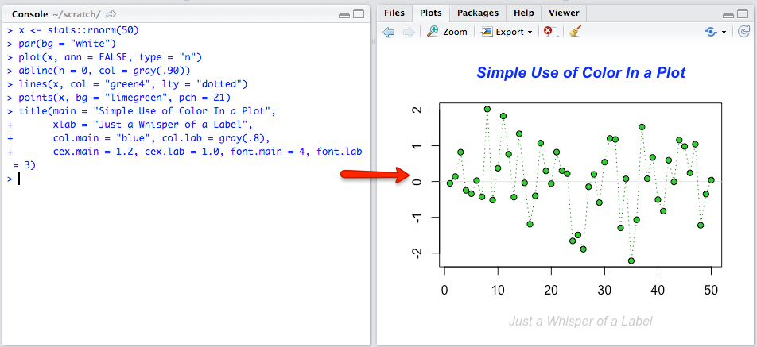

```r
knitr::include_graphics("figures/level-1.png")
```

> - Trabalha direto na console do R
> - Utilização simples do R
> - Não reproduzível

## Nível 2: Usuário Intermediário em R

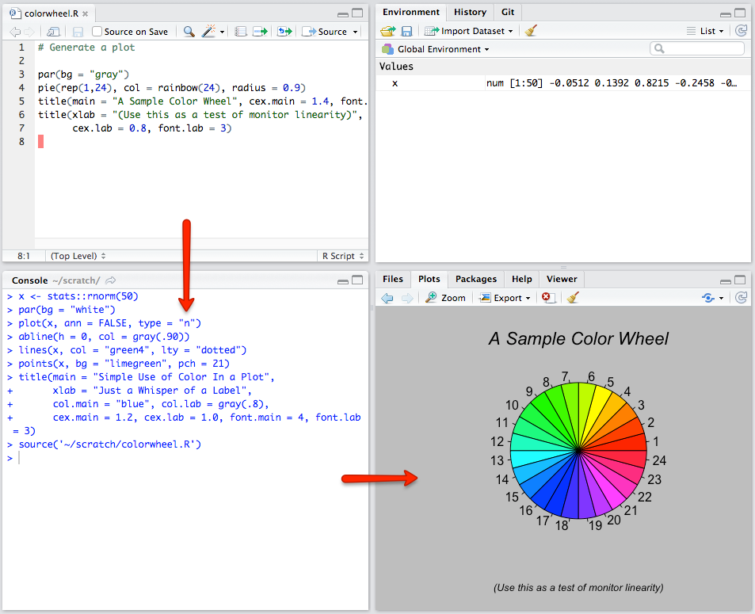

```r
knitr::include_graphics("figures/level-2.png")
```

> - Estrátégia da maioria dos usuários de R
> - Escrever o código em um editor
> - As saídas são salvas separadamente
> - *Export/copy/paste* são necessários
> - Geralmente não há documentação

## Nível 3: Usuário Avançado em R

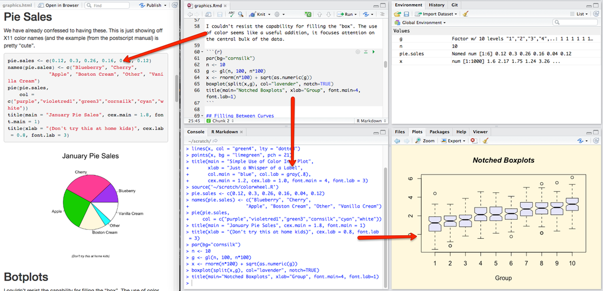

```r
knitr::include_graphics("figures/level-3.png")
```

> - Utiliza ferramentas para integrar código e texto
> - Gera documentos, mas ainda precisa das janelas de comandos e de visualização

## Nível 4: Usuário de R Notebooks

> - Integra código e texto
> - Gera documentos sem depender da console ou do visualizador
> - Usa o *Notebook*

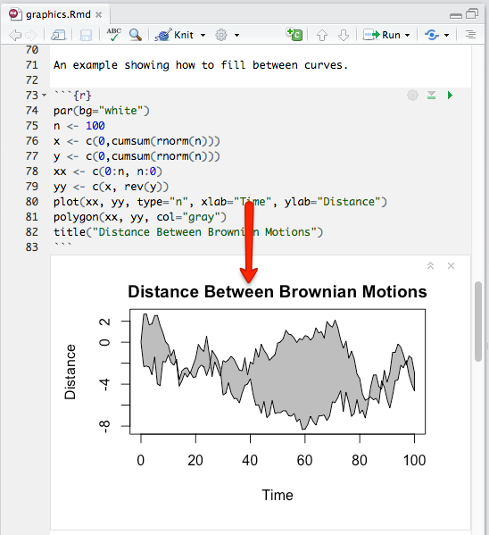

```r
knitr::include_graphics("figures/level-4.png")
```

## R Notebooks Summary

1. Utiliza R Markdown (linguagem de marcação transforma texto em XHTML válido.)
2. Interage com o R em um **fluxo contínuo**.
3. **Interção rápida**; código e resultado juntos.Visualização imediata
4. Gera um **arquivo reproduzível** com boa qualidade (output).
5. **Compartilha e Publica** facilmente.
6. **One-click export** para PDF, Word, etc.

## A melhor ferramenta para análise

> - Um documento HTML (self-contained)
> - Fácil compartilhamento
> - Uso de Funções dinâmicas
> - Veja exemplo: html_dinamico

## Criando um RNotebooks - open

[figure not shown]

```r
knitr::include_graphics("figures/open.png")
```

## Estrutura básica

- Cabeçalho (*YAML*)
- *chunks*
- texto

[figure not shown]

```r
knitr::include_graphics("figures/rnotebook.png")
```

## Cabeçalho - *YAML*

[figure not shown]

```r
knitr::include_graphics("figures/yaml.png")
```

## Cabeçalho - Complementos

- author: “nome”
- date: “11/09/2017”

## O *chunk*

```r
knitr::include_graphics("figures/chunk1.png")
```

[output not shown]

```r
summary(cars)
```

```
##      speed           dist
##  Min.   : 4.0   Min.   :  2.00
##  1st Qu.:12.0   1st Qu.: 26.00
##  Median :15.0   Median : 36.00
##  Mean   :15.4   Mean   : 42.98
##  3rd Qu.:19.0   3rd Qu.: 56.00
##  Max.   :25.0   Max.   :120.00
```

## Incluindo código R no texto

Para executar um código r no texto:

```r
knitr::include_graphics("figures/rnotexto.png")
```

[output not shown]

**O valor máximo em “c(5, 7, 15)” é 15**

## Crie um notebook!

Crie um notebook conforme segue:

1. O titulo deve ser: “Primeiro Notebook”
2. Inclua seu nome como autor (author:)
3. Inclua a data (date:)
4. A primeira seção de ter o título: “Amostra da Distribuição Normal”
5. Então simule 100 valores de uma distribuição Normal(0,1).(use: x=rnorm(100))
6. Outra seção: “Histograma”
7. Faça um histograma (hist(x))
8. Outra seção: “Medidas descritivas”
9. Escreva um paragrafo explicitando:
   - valor da média (mean(x)),
   - desvio padrão (sd(x)),
   - mínimo e máximo (min(x) e max(x)).

## Referências

- RStudio Preview: site: https://www.rstudio.com/products/rstudio/download/preview/
- R Notebooks: site: http://rmarkdown.rstudio.com/r_notebooks.html